# Commuter Flow Map Load Time Comparison

2023-12-13

## Data Sizes

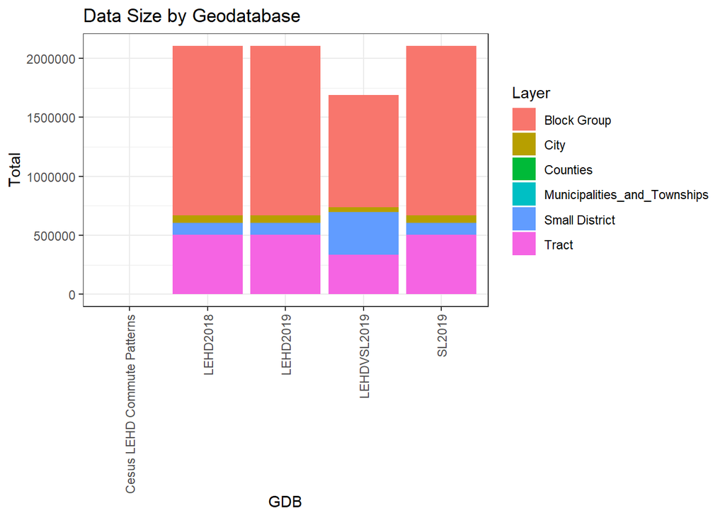

Block group data takes up roughly 65.6% of total data size of the final web app (based on total rows/columns).

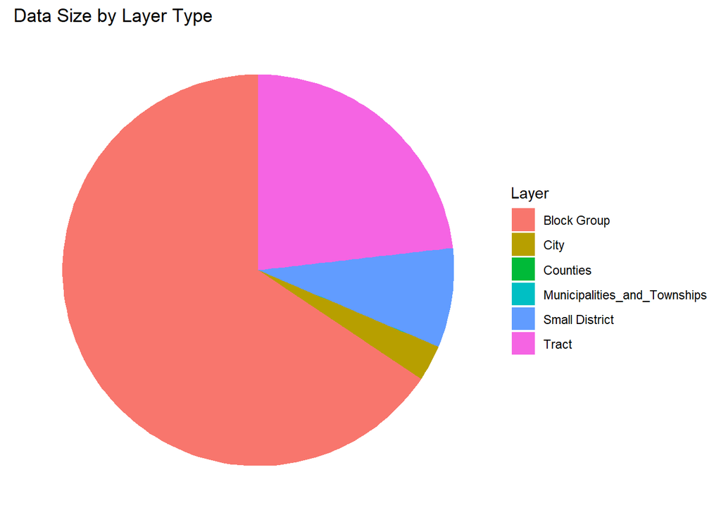

| Layer | gTotal | pct |
| --- | --- | --- |
| Block Group | 5259495 | 65.638469034 |
| City | 237456 | 2.963449590 |
| Counties | 145 | 0.001809599 |
| Municipalities_and_Townships | 776 | 0.009684476 |
| Small District | 657648 | 8.207443468 |
| Tract | 1857304 | 23.179143832 |

## Load Times

Total load time was calculated as the sum of “Load Config” time, “Load Map” time, and “Load Widget” time. The total load time decreased as a result of the following measures:

- Deleting Block Groups from the final web app
- Simplifying all polygon geometries
- Deleting Block groups and simplifying remaining geometries
- Same as 3rd bullet, plus doing the same for 2018 data (I forgot about 2018 data until now)

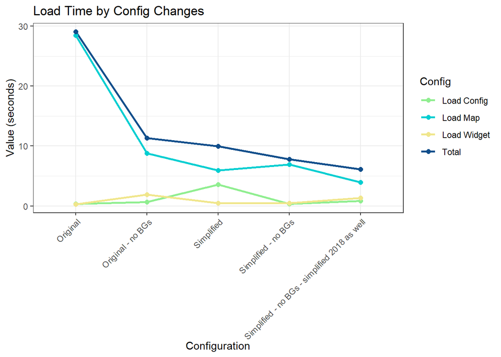

Load time was also calculated using a webspeed test. Load time was calculated as total load time as well as “speed index”. Both are shown below.

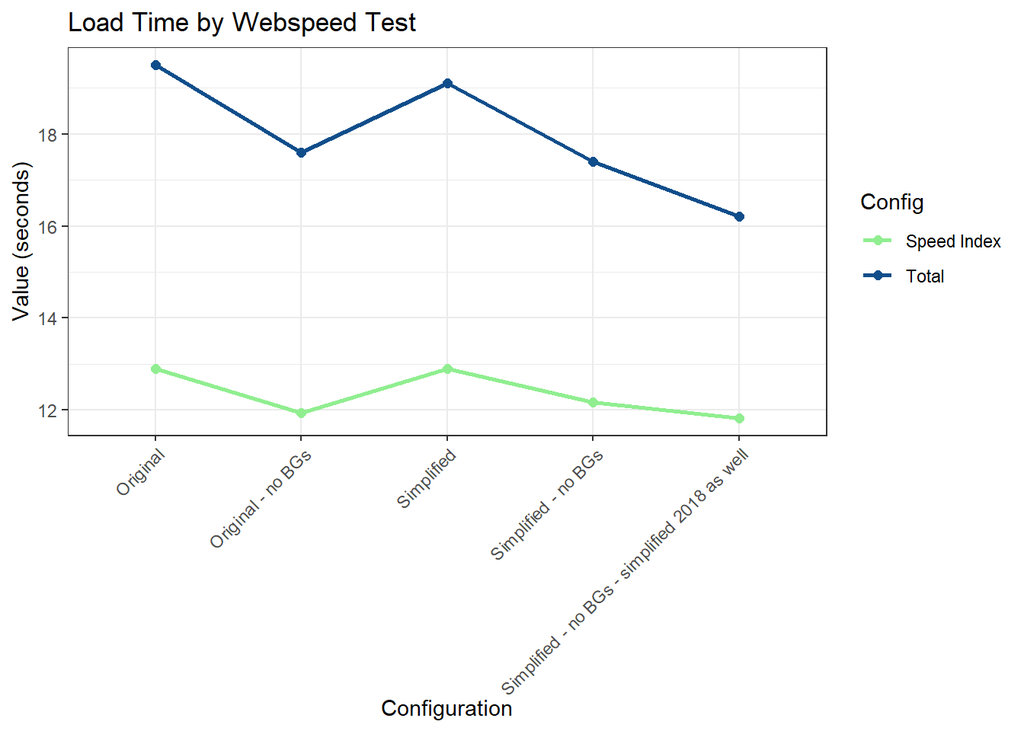

## Results

The final results showed that by eliminating block groups and simplifying geometries, load time decreased about 79%, from 29 seconds to 6 seconds.

| Configuration | Total | Value | pctDecrease | absDecrease |
| --- | --- | --- | --- | --- |
| Original | 29.07 | 29.07 | 0.00000 | 0.00 |
| Original - no BGs | 29.07 | 11.32 | -61.05951 | -17.75 |
| Simplified | 29.07 | 9.97 | -65.70347 | -19.10 |
| Simplified - no BGs | 29.07 | 7.76 | -73.30581 | -21.31 |
| Simplified - no BGs - simplified 2018 as well | 29.07 | 6.12 | -78.94737 | -22.95 |